# Smoothed Lines

David McGaughey

Data from Aaron Rising (Bharti Lab)

## Get data (two xls files) from here:

- https://github.com/davemcg/Let_us_plot/tree/master/002_smoothed_lines
- The rmd is also here if you want the source code

Two different excel files (Cobra and Eel). Pig names?

They have metrics for eye function across time.

Aaron told me to take the ‘first tab’ in each excel file. Which is not the case, as at least to me, ‘Sheet 1’ is empty in both. So I’m using the next tab in both, which is ‘Normalized 2 Base For Comb’

## Load data and look at structure (str)

```r
library(tidyverse)
library(ggsci)

cobra <- readxl::read_xls('data/Cobra 749--_Normalized_Data_.xls', sheet = 'Normalized 2 Base For Comb')
cobra %>% str()
```

```
## tibble [187 × 8] (S3: tbl_df/tbl/data.frame)
##  $ Pig_Name  : chr [1:187] "Cobra 749" "Cobra 749" "Cobra 749" "Cobra 749" ...
##  $ Week      : num [1:187] 0 0 0 0 0 0 0 0 0 0 ...
##  $ Region    : chr [1:187] "Healthy_Implant" "Healthy_Implant" "Healthy_Implant" "Healthy_Implant" ...
##  $ Cells     : logi [1:187] FALSE FALSE FALSE FALSE FALSE FALSE ...
##  $ Output    : chr [1:187] "Area-Under-Curve" "HFC-Scalar" "LFC-Scalar" "N1" ...
##  $ GroupCount: num [1:187] 3 3 3 3 3 3 3 3 3 3 ...
##  $ Data      : num [1:187] 1 1 1 1 15.7 ...
##  $ STD       : num [1:187] 0.0994 0.3493 0.2259 0.1063 0.5774 ...
```

```r
eel <- readxl::read_xls('data/Eel 668--_Normalized_Data_.xls', sheet = 'Normalized 2 Base For Comb')
eel %>% str()
```

```
## tibble [192 × 8] (S3: tbl_df/tbl/data.frame)
##  $ Pig_Name  : chr [1:192] "Eel 668" "Eel 668" "Eel 668" "Eel 668" ...
##  $ Week      : num [1:192] 0 0 0 0 0 0 0 0 0 0 ...
##  $ Region    : chr [1:192] "Healthy_Sham" "Healthy_Sham" "Healthy_Sham" "Healthy_Sham" ...
##  $ Cells     : logi [1:192] FALSE FALSE FALSE FALSE FALSE FALSE ...
##  $ Output    : chr [1:192] "Area-Under-Curve" "HFC-Scalar" "LFC-Scalar" "N1" ...
##  $ GroupCount: num [1:192] 3 3 3 3 3 3 3 3 3 3 ...
##  $ Data      : num [1:192] 1 1 1 1 20.7 ...
##  $ STD       : num [1:192] 0.0537 0.5141 0.1355 0.0631 0.5774 ...
```

## Head (first few lines)

```r
cobra %>% head()
```

```
## # A tibble: 6 × 8
##   Pig_Name   Week Region          Cells Output           GroupCount  Data    STD
##   <chr>     <dbl> <chr>           <lgl> <chr>                 <dbl> <dbl>  <dbl>
## 1 Cobra 749     0 Healthy_Implant FALSE Area-Under-Curve          3   1   0.0994
## 2 Cobra 749     0 Healthy_Implant FALSE HFC-Scalar                3   1   0.349
## 3 Cobra 749     0 Healthy_Implant FALSE LFC-Scalar                3   1   0.226
## 4 Cobra 749     0 Healthy_Implant FALSE N1                        3   1   0.106
## 5 Cobra 749     0 Healthy_Implant FALSE N1-Latency                3  15.7 0.577
## 6 Cobra 749     0 Healthy_Implant FALSE N1-Prom                   3   1   0.177
```

```r
eel %>% head()
```

```
## # A tibble: 6 × 8
##   Pig_Name  Week Region       Cells Output           GroupCount  Data    STD
##   <chr>    <dbl> <chr>        <lgl> <chr>                 <dbl> <dbl>  <dbl>
## 1 Eel 668      0 Healthy_Sham FALSE Area-Under-Curve          3   1   0.0537
## 2 Eel 668      0 Healthy_Sham FALSE HFC-Scalar                3   1   0.514
## 3 Eel 668      0 Healthy_Sham FALSE LFC-Scalar                3   1   0.135
## 4 Eel 668      0 Healthy_Sham FALSE N1                        3   1   0.0631
## 5 Eel 668      0 Healthy_Sham FALSE N1-Latency                3  20.7 0.577
## 6 Eel 668      0 Healthy_Sham FALSE N1-Prom                   3   1   0.0781
```

Looks like we have implant (cobra) vs sham (eel)?

We have several types of `Output` (Area-Under-Curve, HFC-Scalar, LFC-Scalar, N1, N1-Latency, N1-Prom, N1-Width, N1P1, N2, N2-Latency, N2-Prom, N2-Width, N2P2, P1, P1-Latency, P1-Prom, P1-Width, P1N2, P2, P2-Latency, P2-Prom, P2-Width, Pos.-Area-Under-Curve, RMS-HFC) which are different variables that have been measured. I asked Aaron what he cared most about and he suggested AUC, N1P1, and Latency

## AUC, N1P1, Latency

We need to get the exact names for those variables

We can extract all of the `Output` values and only print the unique ones

```r
eel$Output %>% unique()
```

```
##  [1] "Area-Under-Curve"      "HFC-Scalar"            "LFC-Scalar"
##  [4] "N1"                    "N1-Latency"            "N1-Prom"
##  [7] "N1-Width"              "N1P1"                  "N2"
## [10] "N2-Latency"            "N2-Prom"               "N2-Width"
## [13] "N2P2"                  "P1"                    "P1-Latency"
## [16] "P1-Prom"               "P1-Width"              "P1N2"
## [19] "P2"                    "P2-Latency"            "P2-Prom"
## [22] "P2-Width"              "Pos.-Area-Under-Curve" "RMS-HFC"
```

OK, so `Area-Under-Curve`, `N1P1`, and `N1-Latency` are the three variables we’ll take a look at. Or fewer if I get confused.

Let’s start by just looking at AUC. Generically it is a machine learning measure of how often an algorithm will distinguish the right answer over the wrong one. 1 is perfect. 0 is perfect wrong. 0.5 is a monkey flipping coins. Not sure what it means here.

## Summary of eel and cobra AUC

Get the summary data from just the AUC values for each pig

```r
cobra %>% filter(Output == 'Area-Under-Curve') %>% pull(Data) %>% summary()
```

```
##    Min. 1st Qu.  Median    Mean 3rd Qu.    Max.
##  0.3653  0.4629  0.6895  0.6989  0.9675  1.0000
```

```r
eel %>% filter(Output == 'Area-Under-Curve') %>% pull(Data) %>% summary()
```

```
##    Min. 1st Qu.  Median    Mean 3rd Qu.    Max.
##  0.6022  0.7717  0.9596  0.8698  0.9959  1.0000
```

So the sham (eel) has a better AUC?

## What kind of time points or conditions or whatever do we have again?

```r
cobra %>% filter(Output == 'Area-Under-Curve')
```

```
## # A tibble: 8 × 8
##   Pig_Name   Week Region          Cells Output           GroupCount  Data    STD
##   <chr>     <dbl> <chr>           <lgl> <chr>                 <dbl> <dbl>  <dbl>
## 1 Cobra 749     0 Healthy_Implant FALSE Area-Under-Curve          3 1     0.0994
## 2 Cobra 749    14 Healthy_Implant FALSE Area-Under-Curve          3 0.690 0.0877
## 3 Cobra 749    35 Healthy_Implant FALSE Area-Under-Curve          3 0.689 0.119
## 4 Cobra 749    58 Healthy_Implant FALSE Area-Under-Curve          3 0.957 0.208
## 5 Cobra 749     0 Implant_NoLx    FALSE Area-Under-Curve          3 1     0.0868
## 6 Cobra 749    14 Implant_NoLx    FALSE Area-Under-Curve          3 0.365 0.0964
## 7 Cobra 749    35 Implant_NoLx    FALSE Area-Under-Curve          3 0.409 0.102
## 8 Cobra 749    58 Implant_NoLx    FALSE Area-Under-Curve          3 0.481 0.212
```

Oh, we have *two kinds or regions*. Didn’t see that before. So the above summary doesn’t take that into account.

## Summary by pig and region

This summary is `group_by(Region)` so we’ll get summary data (`mean` and `median`) by Region now

```r
cobra %>% filter(Output == 'Area-Under-Curve') %>% group_by(Region) %>% summarise(mean = mean(Data), median= median(Data))
```

```
## # A tibble: 2 × 3
##   Region           mean median
##   <chr>           <dbl>  <dbl>
## 1 Healthy_Implant 0.834  0.823
## 2 Implant_NoLx    0.564  0.445
```

```r
eel %>% filter(Output == 'Area-Under-Curve') %>% group_by(Region) %>% summarise(mean = mean(Data), median= median(Data))
```

```
## # A tibble: 2 × 3
##   Region        mean median
##   <chr>        <dbl>  <dbl>
## 1 Healthy_Sham 0.978  0.992
## 2 Implant-Sham 0.761  0.721
```

We also have time (Week). This will be our x axis when we plot, as this data is sampled across time

## Plot AUC by time and region and pig

x axis is time, y axis is AUC, and split by region/pig

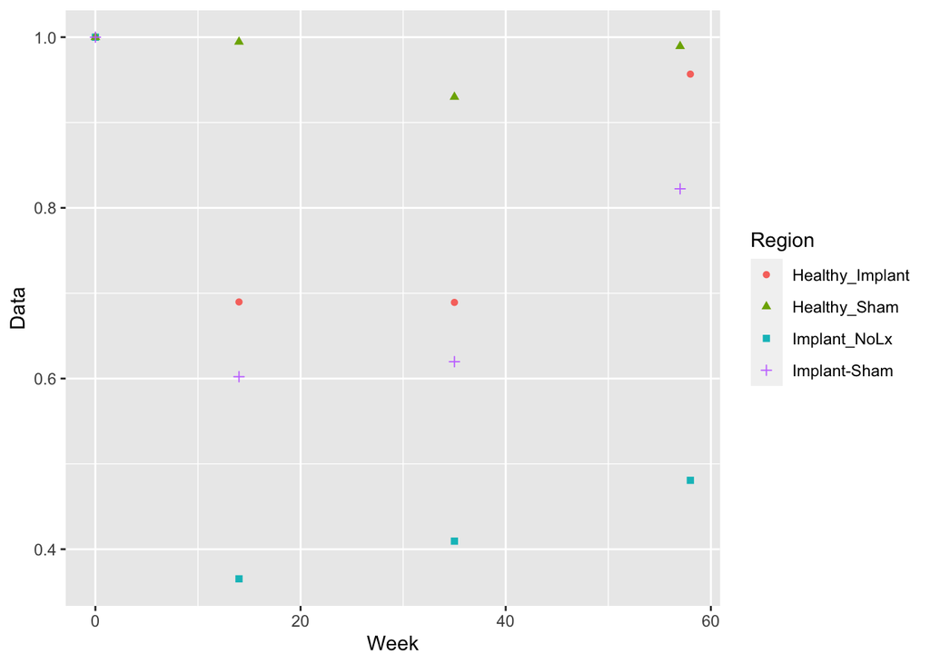

```r
cobra_eel_AUC <- rbind(cobra %>% filter(Output == 'Area-Under-Curve'),
                       eel %>% filter(Output == 'Area-Under-Curve'))
cobra_eel_AUC %>%
  ggplot(aes(x=Week, y=Data, shape=Region, colour=Region)) +
   geom_point()
```

## Prettier plot with lines and more formatting

Using the ggsci library with the Nature Publishing Group color scheme (`scale_colour_npg()`)

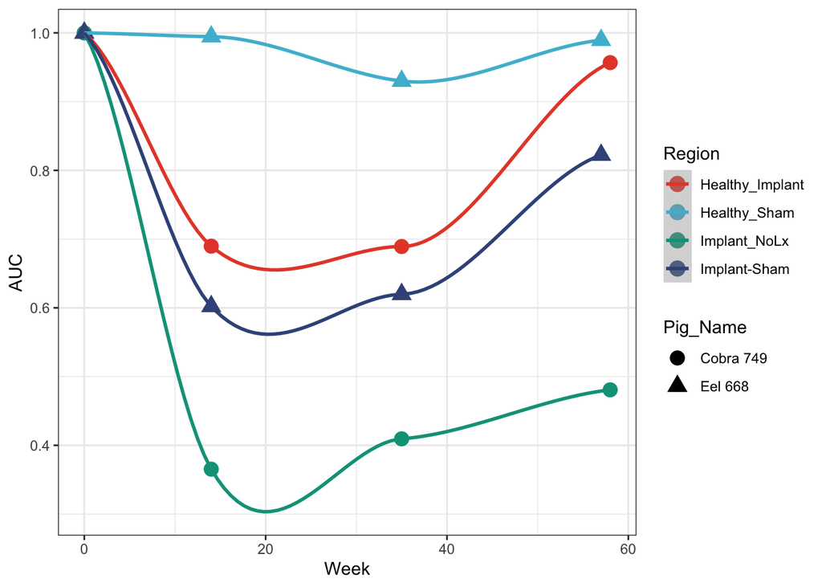

```r
cobra_eel_AUC %>%
  ggplot(aes(x=Week, y=Data, colour=Region, shape = Pig_Name)) +
  geom_point(size=4) +
  geom_smooth(method = 'loess') + ## this draws the smoothed lines through the four points. It auto picks an algorithm that works. loess was used here
  theme_bw() + scale_colour_npg() +
  ylab('AUC')
```

## N1P1 Plot

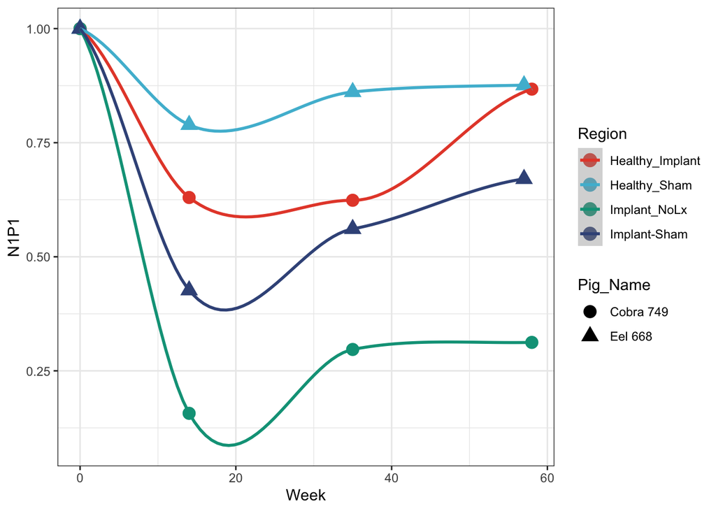

```r
rbind(cobra %>% filter(Output == 'N1P1'), eel %>% filter(Output == 'N1P1')) %>%
  ggplot(aes(x=Week, y=Data, colour=Region, shape = Pig_Name)) +
  geom_point(size=4) +
  geom_smooth() + ## this draws the smoothed lines through the four points. It auto picks an algorithm that works. loess was used here
  theme_bw() + scale_colour_npg() +
  ylab('N1P1')
```

## Latency plot

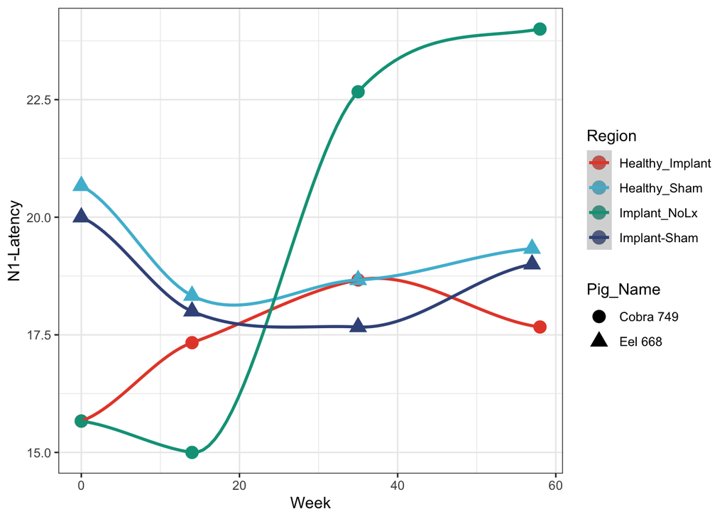

```r
rbind(cobra %>% filter(Output == 'N1-Latency'), eel %>% filter(Output == 'N1-Latency')) %>%
  ggplot(aes(x=Week, y=Data, colour=Region, shape = Pig_Name)) +
  geom_point(size=4) +
  geom_smooth() + ## this draws the smoothed lines through the four points. It auto picks an algorithm that works. loess was used here
  theme_bw() + scale_colour_npg() +
  ylab('N1-Latency')
```

## Bonus

We have many variables. We can get a quick sense of how all of the variables separate out the major data categories with a PCA

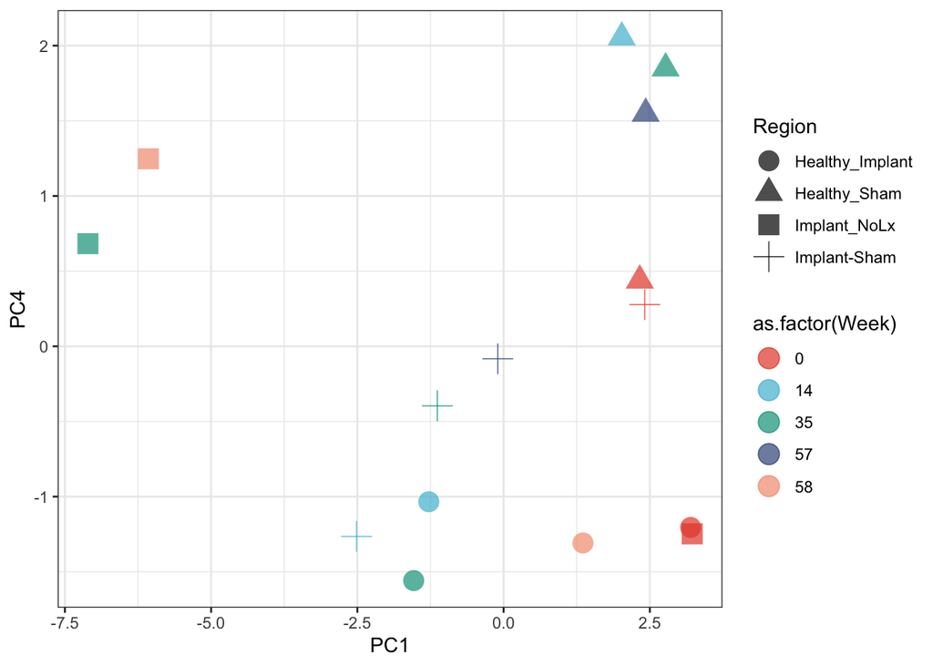

```r
all_pigs <- rbind(cobra, eel) %>%
  select(Region, Pig_Name, Week, Output, Data) %>%
  spread(Output, Data)
## toss P-Prime-Latency column
all_pigs <- all_pigs %>% select(-`P-Prime-Latency`)
## remove columns with NA
all_pigs <- all_pigs[complete.cases(all_pigs), complete.cases(t(all_pigs))]
pca <- prcomp(all_pigs[,4:ncol(all_pigs)], scale. = T)

## pull out PCA coordinates (pca$x) and add to all_pigs with the cbind
all_pigs <- cbind(all_pigs, pca$x)

ggplot(all_pigs, aes(x=PC1, y=PC4, color=as.factor(Week), shape=Region)) +
  geom_point(size=5, alpha=0.7) +
  theme_bw() +
  scale_colour_npg()
```